# Project: TMDb Movie Data Analysis

- Introduction
- Data Wrangling
- Exploratory Data Analysis
- Conclusions

## Introduction

I choose the **TMDb movie data** to do the analysis, and I will answer the following questions:

1. What kinds of properties are associated with movies that have high revenues?
2. The highest profit in which year is acheived?
3. Which genres are most produced from year to year?, and which genres achieve the highest mean revenue?

```python
# import needed libraries
import pandas as pd
import numpy as np
import matplotlib.pyplot as plt
%matplotlib inline
```

## Data Wrangling

### General Properties

```python
# Load the data and print out a few lines.
df_moives = pd.read_csv('./data/tmdb-movies.csv')
df_moives.head()
```

|  | id | imdb_id | popularity | budget | revenue | original_title | cast | homepage | director | tagline | ... | overview | runtime | genres | production_companies | release_date | vote_count | vote_average | release_year | budget_adj | revenue_adj |
| --- | --- | --- | --- | --- | --- | --- | --- | --- | --- | --- | --- | --- | --- | --- | --- | --- | --- | --- | --- | --- | --- |
| 0 | 135397 | tt0369610 | 32.985763 | 150000000 | 1513528810 | Jurassic World | Chris Pratt\|Bryce Dallas Howard\|Irrfan Khan\|Vi... | http://www.jurassicworld.com/ | Colin Trevorrow | The park is open. | ... | Twenty-two years after the events of Jurassic ... | 124 | Action\|Adventure\|Science Fiction\|Thriller | Universal Studios\|Amblin Entertainment\|Legenda... | 6/9/15 | 5562 | 6.5 | 2015 | 1.379999e+08 | 1.392446e+09 |
| 1 | 76341 | tt1392190 | 28.419936 | 150000000 | 378436354 | Mad Max: Fury Road | Tom Hardy\|Charlize Theron\|Hugh Keays-Byrne\|Nic... | http://www.madmaxmovie.com/ | George Miller | What a Lovely Day. | ... | An apocalyptic story set in the furthest reach... | 120 | Action\|Adventure\|Science Fiction\|Thriller | Village Roadshow Pictures\|Kennedy Miller Produ... | 5/13/15 | 6185 | 7.1 | 2015 | 1.379999e+08 | 3.481613e+08 |
| 2 | 262500 | tt2908446 | 13.112507 | 110000000 | 295238201 | Insurgent | Shailene Woodley\|Theo James\|Kate Winslet\|Ansel... | http://www.thedivergentseries.movie/#insurgent | Robert Schwentke | One Choice Can Destroy You | ... | Beatrice Prior must confront her inner demons ... | 119 | Adventure\|Science Fiction\|Thriller | Summit Entertainment\|Mandeville Films\|Red Wago... | 3/18/15 | 2480 | 6.3 | 2015 | 1.012000e+08 | 2.716190e+08 |
| 3 | 140607 | tt2488496 | 11.173104 | 200000000 | 2068178225 | Star Wars: The Force Awakens | Harrison Ford\|Mark Hamill\|Carrie Fisher\|Adam D... | http://www.starwars.com/films/star-wars-episod... | J.J. Abrams | Every generation has a story. | ... | Thirty years after defeating the Galactic Empi... | 136 | Action\|Adventure\|Science Fiction\|Fantasy | Lucasfilm\|Truenorth Productions\|Bad Robot | 12/15/15 | 5292 | 7.5 | 2015 | 1.839999e+08 | 1.902723e+09 |
| 4 | 168259 | tt2820852 | 9.335014 | 190000000 | 1506249360 | Furious 7 | Vin Diesel\|Paul Walker\|Jason Statham\|Michelle ... | http://www.furious7.com/ | James Wan | Vengeance Hits Home | ... | Deckard Shaw seeks revenge against Dominic Tor... | 137 | Action\|Crime\|Thriller | Universal Pictures\|Original Film\|Media Rights ... | 4/1/15 | 2947 | 7.3 | 2015 | 1.747999e+08 | 1.385749e+09 |

5 rows × 21 columns

I did the following to clean the data.

#### 1. Drop irrelevant columns

These columns [id, imdb_id, homepage, tagline, release_date. keywords, overview, budget, revenue] will be dropped because it will not be used to answer the questions.

```python
# here is the list of columns that I need to remove
columns_name_to_be_dropped = ['id', 'imdb_id', 'homepage', 'tagline', 'release_date',
                              'keywords', 'overview', 'budget', 'revenue']
df_moives.drop(columns=columns_name_to_be_dropped, axis=1, inplace=True)

#to make sure that the columns have been dropped
df_moives.columns
```

```
Index(['popularity', 'original_title', 'cast', 'director', 'runtime', 'genres',
       'production_companies', 'vote_count', 'vote_average', 'release_year',
       'budget_adj', 'revenue_adj'],
      dtype='object')
```

#### 2. Drop NA rows

I need first to now what values are null in the database, and then drop it.

```python
print(" Shape of data Before Dropping null: " , df_moives.shape , "\n\n", "Data info:", '\n')
df_moives.info()
```

```
 Shape of data Before Dropping null:  (10866, 12)

 Data info:

<class 'pandas.core.frame.DataFrame'>
RangeIndex: 10866 entries, 0 to 10865
Data columns (total 12 columns):
 #   Column                Non-Null Count  Dtype
---  ------                --------------  -----
 0   popularity            10866 non-null  float64
 1   original_title        10866 non-null  object
 2   cast                  10790 non-null  object
 3   director              10822 non-null  object
 4   runtime               10866 non-null  int64
 5   genres                10843 non-null  object
 6   production_companies  9836 non-null   object
 7   vote_count            10866 non-null  int64
 8   vote_average          10866 non-null  float64
 9   release_year          10866 non-null  int64
 10  budget_adj            10866 non-null  float64
 11  revenue_adj           10866 non-null  float64
dtypes: float64(4), int64(3), object(5)
memory usage: 1018.8+ KB
```

```python
df_moives.dropna(inplace=True)
```

```python
print(" Shape of data After Dropping null: " , df_moives.shape , "\n\n", "Data info:", '\n')
df_moives.info()
print("\n\nAs you can see there is no null vlaues ^_^, and based on isnull() function there is \
no null values" ,df_moives.isnull().sum().any())
```

```
 Shape of data After Dropping null:  (9773, 12)

 Data info:

<class 'pandas.core.frame.DataFrame'>
Int64Index: 9773 entries, 0 to 10865
Data columns (total 12 columns):
 #   Column                Non-Null Count  Dtype
---  ------                --------------  -----
 0   popularity            9773 non-null   float64
 1   original_title        9773 non-null   object
 2   cast                  9773 non-null   object
 3   director              9773 non-null   object
 4   runtime               9773 non-null   int64
 5   genres                9773 non-null   object
 6   production_companies  9773 non-null   object
 7   vote_count            9773 non-null   int64
 8   vote_average          9773 non-null   float64
 9   release_year          9773 non-null   int64
 10  budget_adj            9773 non-null   float64
 11  revenue_adj           9773 non-null   float64
dtypes: float64(4), int64(3), object(5)
memory usage: 992.6+ KB


As you can see there is no null vlaues ^_^, and based on isnull() function there is no null values False
```

#### 3. Check if there is duplicated rows and drop it.

```python
#to check the number of duplicated rows
df_moives.duplicated().sum()
```

```
1
```

```python
#drop duplicated rows
df_moives.drop_duplicates(inplace=True)
```

```python
print("to make sure that the duplicated value has been removed")
df_moives.shape
```

```
to make sure that the duplicated value has been removed
```

```
(9772, 12)
```

```python
# I want to save the data after clean it in new csv to use it
df_moives.to_csv('./data/moives_data_after_cleaning.csv', index=False)
```

#### 4.Check Data Types

```python
df_moives.dtypes
```

```
popularity              float64
original_title           object
cast                     object
director                 object
runtime                   int64
genres                   object
production_companies     object
vote_count                int64
vote_average            float64
release_year              int64
budget_adj              float64
revenue_adj             float64
dtype: object
```

It is look like all column have the right data type, so we will move to anther step.

#### Format number function

```python
# number_format function is to print numbers with commas as thousands
def number_format(number):
    return format(int(float(number)),",")
```

## Exploratory Data Analysis

### Research Question 1 : What kinds of properties are associated with movies that have high revenues?

This is a big question, so we need to split it to small questions like:

#### What is the relationship between popularity and revenues

```python
#desribe popularity
df_moives.popularity.describe()
```

```
count    9772.000000
mean        0.694721
std         1.036931
min         0.000188
25%         0.232710
50%         0.419762
75%         0.776408
max        32.985763
Name: popularity, dtype: float64
```

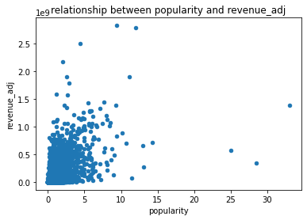

```python
#plot the realtionship bettween popularity and revenue_adj
df_moives.plot(kind='scatter', x='popularity', y='revenue_adj', title='relationship between popularity and revenue_adj');
```

As you can see the 75% = 0.776408 yet the max = 32.985763, and in the plot there is number of outlier started from 7; as a result I will make query for the moives that there popularity < 7, and plot them.

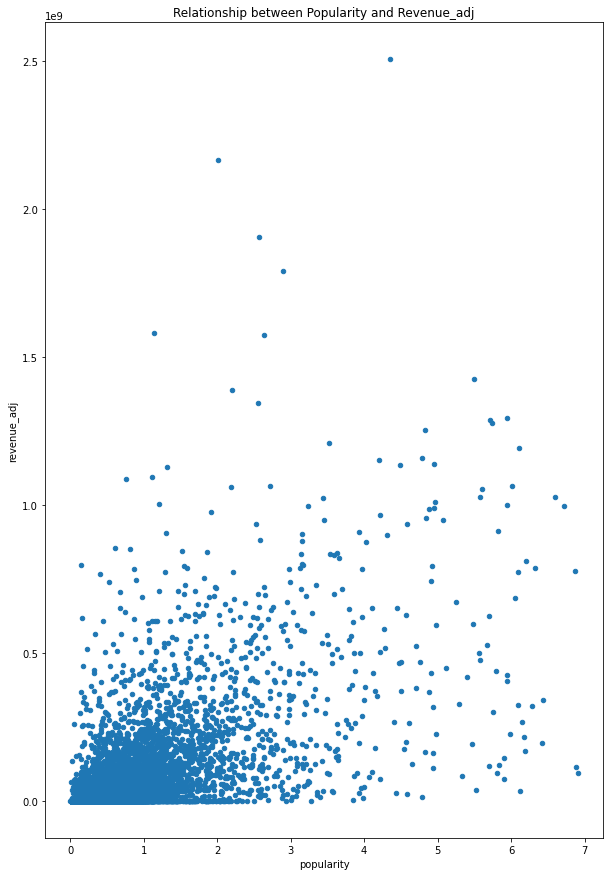

```python
#using query to filter the moives that their (popularity < 7) and then plot it
pop_less_than7_df = df_moives.query('popularity < 7')
pop_less_than7_df.plot(kind='scatter', x='popularity', y='revenue_adj', figsize=(10,15),
                  title='Relationship between Popularity and Revenue_adj');
```

From the plot above you can see the positive realtionship between popularity and revenue

#### What is the relationship between runtime and high revenues

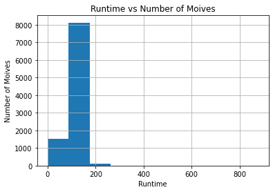

```python
#plot histgram to draw the runtime vs the number of moives
df_moives.runtime.hist()
plt.title("Runtime vs Number of Moives")
plt.xlabel('Runtime')
plt.ylabel('Number of Moives');
```

```python
# describe the runtime attribute
df_moives.runtime.describe()
```

```
count    9772.000000
mean      102.926627
std        27.877432
min         0.000000
25%        90.000000
50%       100.000000
75%       112.000000
max       877.000000
Name: runtime, dtype: float64
```

As you can see using describe function and above histgram the most moives runtime between 0 and 112

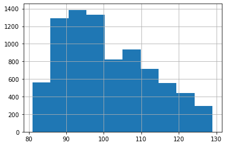

```python
#using trial and error we can seet that the most moives their runtime between 80 and 130
df_moives.query('runtime > 80 & runtime < 130').runtime.hist();
```

```python
# first we want to filter the highest moive revenue based on median
revenue_median = df_moives.revenue_adj.median()
revenue_median
```

```
0.0
```

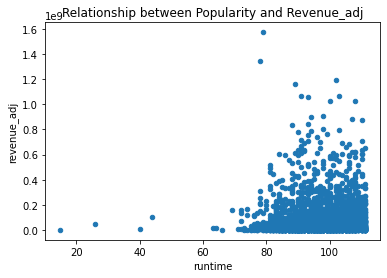

```python
#here I filtered the high revenues based on revenue > revenue_median and the runtime bettween 0 and 112(min, and 3rd quarter)
df_high_revenues =  df_moives.query('revenue_adj > {} & runtime < {} & runtime > {}'.format(revenue_median, 112, 0))
df_high_revenues.plot(kind='scatter', x='runtime', y='revenue_adj',
                  title='Relationship between Popularity and Revenue_adj');
```

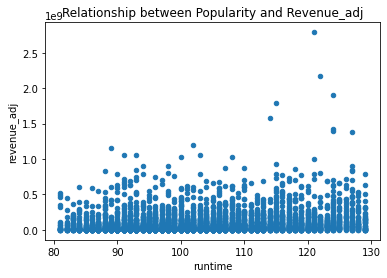

```python
#Here i reduce the filltered runtime to be bettween 80 and 130.
df_high_revenues =  df_moives.query('revenue_adj > {} & runtime < {} & runtime > {}'.format(revenue_median, 130, 80))
df_high_revenues.plot(kind='scatter', x='runtime', y='revenue_adj',
                  title='Relationship between Popularity and Revenue_adj');
```

As you can see from above figures the moives with runtime > 80 and < 130 proudce higher revenues

#### What level of vote_averge receives the highest mean revenue?

```python
# View the min, 25%, 50%, 75%, max vote_average values with Pandas describe
df_moives.vote_average.describe()
```

```
count    9772.000000
mean        5.963528
std         0.913174
min         1.500000
25%         5.400000
50%         6.000000
75%         6.600000
max         8.700000
Name: vote_average, dtype: float64
```

```python
# Bin edges that will be used to "cut" the data into groups
bin_edges = [1.5, 5.4, 6.0, 6.6, 8.7]

# Labels for the four vote_averge level groups
bin_names = ['Low', 'Median', 'Moderately High', 'High']

# Creates vote_levels column
df_moives['vote_levels'] = pd.cut(df_moives['vote_average'], bin_edges, labels=bin_names)

# Find the mean revenue_adj of each vote level with groupby
df_moives.groupby('vote_levels').mean()['revenue_adj']
```

```
vote_levels
Low                1.738698e+07
Median             4.601794e+07
Moderately High    6.913363e+07
High               1.017821e+08
Name: revenue_adj, dtype: float64
```

### Research Question 2 : The highest profit in which year is acheived?

```python
#first I want to add profit columns which is equal to
df_moives['profit'] = df_moives['revenue_adj']-df_moives['budget_adj']
```

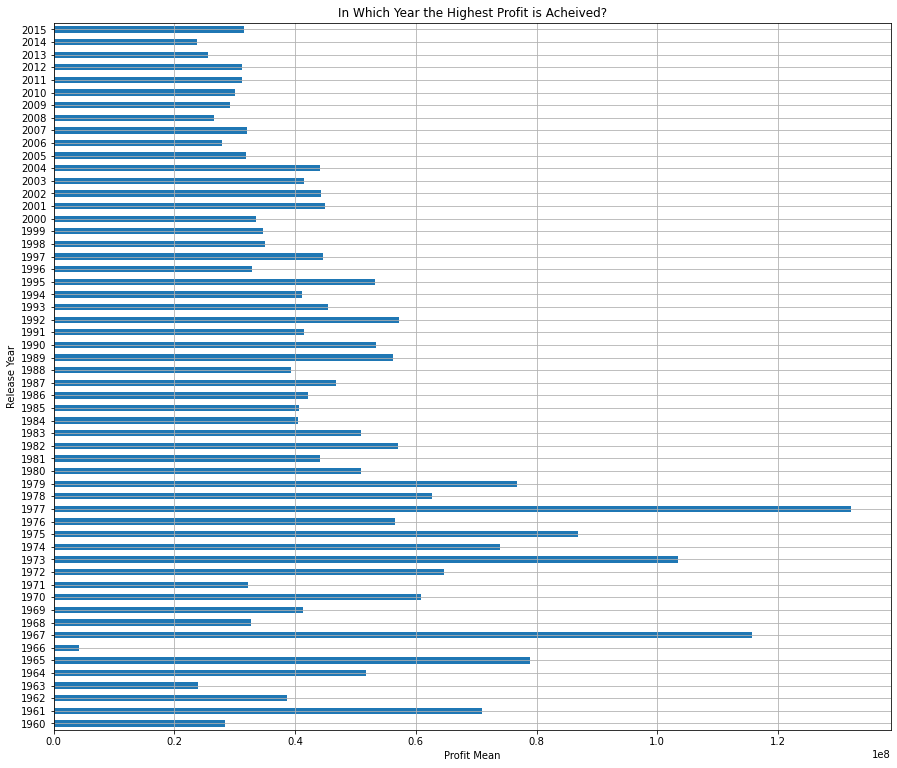

```python
#find the highest year's profit using groupby and plot it.
df_moives.groupby('release_year').profit.mean().plot(kind='barh', figsize=(15,13))
plt.title('In Which Year the Highest Profit is Acheived?')
plt.xlabel('Profit Mean')
plt.ylabel('Release Year')
plt.grid(True);
```

```python
# find the year with highest proift and the highest profit mean value
profit_mean = df_moives.groupby('release_year').profit.mean()
max_year, max_value = profit_mean.idxmax(), profit_mean.max()
print("The highest profit mean is {}$ and it was in {}".format(number_format(max_value), max_year))
```

```
The highest profit mean is 132,071,477$ and it was in 1977
```

As we can see from **In Which Year the Highest Profit is Acheived?** in the above, and the execution for the cell above, you can notice that 1977 was the year which the moives give the highest profit with mean value = 132,071,477$

### Research Question 3: Which genres are most produced from year to year?, and which genres achieve the highest mean revenue

```python
#To answer this question, I need first to use the data that I saved it after cleaning step,
# because I add new columns in anther steps that I do not need to in this step
df_moives2 = pd.read_csv('./data/moives_data_after_cleaning.csv')
```

```python
#to make sure that is the data I need
df_moives2.head(1)
```

|  | popularity | original_title | cast | director | runtime | genres | production_companies | vote_count | vote_average | release_year | budget_adj | revenue_adj |
| --- | --- | --- | --- | --- | --- | --- | --- | --- | --- | --- | --- | --- |
| 0 | 32.985763 | Jurassic World | Chris Pratt\|Bryce Dallas Howard\|Irrfan Khan\|Vi... | Colin Trevorrow | 124 | Action\|Adventure\|Science Fiction\|Thriller | Universal Studios\|Amblin Entertainment\|Legenda... | 5562 | 6.5 | 2015 | 1.379999e+08 | 1.392446e+09 |

To answer this question I need first to **Seperate (genres, production_companies) to multiple rows**

For example in geners column row 0, there is this data (Action|Adventure|Science Fiction|Thriller), I want to seperate this data to multiple rows with the same data except for geners first row -> Action, second one -> Adventure ....

To do this step I make a search, and at last use the code in this [site](https://stackoverflow.com/questions/53860398/pandas-dataframe-how-do-i-split-one-row-into-multiple-rows-by-multi-value-colum/53860543)

```python
#split 'genres' based on |
df_moives2['genres'] = df_moives2['genres'].str.split('|')

#to set index all columns except the genres
other_columns = df_moives2.columns.tolist()
other_columns.remove('genres')

#level_11, 11 is the number of attribues except the genres
df_moives2 = (df_moives2
    .set_index(other_columns)['genres']
    .apply(pd.Series)
    .stack()
    .reset_index()
    .drop('level_11', axis=1)
    .rename(columns={0:'genres'}))
```

```python
# to make sure that  the split took place
df_moives2.head()
```

|  | popularity | original_title | cast | director | runtime | production_companies | vote_count | vote_average | release_year | budget_adj | revenue_adj | genres |
| --- | --- | --- | --- | --- | --- | --- | --- | --- | --- | --- | --- | --- |
| 0 | 32.985763 | Jurassic World | Chris Pratt\|Bryce Dallas Howard\|Irrfan Khan\|Vi... | Colin Trevorrow | 124 | Universal Studios\|Amblin Entertainment\|Legenda... | 5562 | 6.5 | 2015 | 1.379999e+08 | 1.392446e+09 | Action |
| 1 | 32.985763 | Jurassic World | Chris Pratt\|Bryce Dallas Howard\|Irrfan Khan\|Vi... | Colin Trevorrow | 124 | Universal Studios\|Amblin Entertainment\|Legenda... | 5562 | 6.5 | 2015 | 1.379999e+08 | 1.392446e+09 | Adventure |
| 2 | 32.985763 | Jurassic World | Chris Pratt\|Bryce Dallas Howard\|Irrfan Khan\|Vi... | Colin Trevorrow | 124 | Universal Studios\|Amblin Entertainment\|Legenda... | 5562 | 6.5 | 2015 | 1.379999e+08 | 1.392446e+09 | Science Fiction |
| 3 | 32.985763 | Jurassic World | Chris Pratt\|Bryce Dallas Howard\|Irrfan Khan\|Vi... | Colin Trevorrow | 124 | Universal Studios\|Amblin Entertainment\|Legenda... | 5562 | 6.5 | 2015 | 1.379999e+08 | 1.392446e+09 | Thriller |
| 4 | 28.419936 | Mad Max: Fury Road | Tom Hardy\|Charlize Theron\|Hugh Keays-Byrne\|Nic... | George Miller | 120 | Village Roadshow Pictures\|Kennedy Miller Produ... | 6185 | 7.1 | 2015 | 1.379999e+08 | 3.481613e+08 | Action |

#### Which genres are most produced from year to year?

```python
# to see what genres we have in the data.
genres_value_count = df_moives2.genres.value_counts()
genres_value_count
```

```
Drama              4364
Comedy             3433
Thriller           2746
Action             2235
Romance            1570
Horror             1526
Adventure          1384
Crime              1299
Science Fiction    1136
Family             1095
Fantasy             840
Mystery             773
Animation           617
Music               339
Documentary         317
History             306
War                 258
Western             160
TV Movie            132
Foreign             120
Name: genres, dtype: int64
```

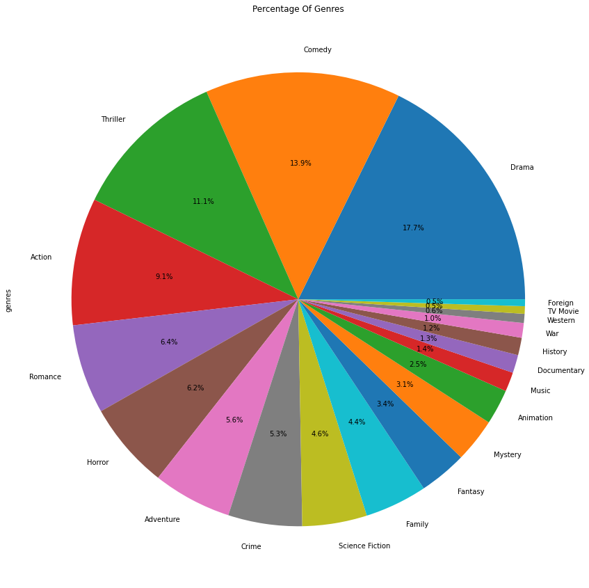

```python
#plot the geners as pie to see which geners are the most produced at all
genres_value_count.plot(kind='pie', figsize=(15, 15), title="Percentage Of Genres",autopct="%1.1f%%");
```

As you can see in figure above **DRAMA** is the most geners that have been produced over all years with precentage = 17.7%

```python
#to know what is the most produced genres year by year
df_moives2.groupby('release_year')['genres'].describe()
```

| release_year | count | unique | top | freq |
| --- | --- | --- | --- | --- |
| 1960 | 78 | 16 | Drama | 13 |
| 1961 | 72 | 17 | Drama | 16 |
| 1962 | 76 | 17 | Drama | 19 |
| 1963 | 91 | 17 | Comedy | 13 |
| 1964 | 110 | 18 | Drama | 20 |
| 1965 | 89 | 17 | Drama | 19 |
| 1966 | 114 | 18 | Drama | 15 |
| 1967 | 92 | 17 | Drama | 16 |
| 1968 | 90 | 17 | Drama | 19 |
| 1969 | 76 | 18 | Drama | 13 |
| 1970 | 107 | 20 | Drama | 19 |
| 1971 | 129 | 18 | Drama | 30 |
| 1972 | 89 | 15 | Drama | 16 |
| 1973 | 140 | 18 | Drama | 31 |
| 1974 | 123 | 19 | Drama | 21 |
| 1975 | 110 | 18 | Drama | 17 |
| 1976 | 121 | 19 | Drama | 22 |
| 1977 | 143 | 18 | Drama | 23 |
| 1978 | 167 | 20 | Drama | 28 |
| 1979 | 141 | 16 | Drama | 30 |
| 1980 | 193 | 18 | Drama | 32 |
| 1981 | 188 | 18 | Drama | 32 |
| 1982 | 211 | 20 | Drama | 33 |
| 1983 | 203 | 19 | Drama | 34 |
| 1984 | 273 | 17 | Comedy | 37 |
| 1985 | 270 | 17 | Comedy | 50 |
| 1986 | 293 | 17 | Drama | 48 |
| 1987 | 307 | 18 | Comedy | 53 |
| 1988 | 338 | 19 | Comedy | 65 |
| 1989 | 354 | 19 | Comedy | 59 |
| 1990 | 353 | 19 | Drama | 58 |
| 1991 | 343 | 19 | Drama | 62 |
| 1992 | 351 | 18 | Drama | 63 |
| 1993 | 463 | 18 | Drama | 89 |
| 1994 | 484 | 20 | Comedy | 83 |
| 1995 | 467 | 19 | Drama | 92 |
| 1996 | 508 | 19 | Drama | 100 |
| 1997 | 494 | 19 | Drama | 78 |
| 1998 | 527 | 20 | Drama | 97 |
| 1999 | 543 | 20 | Drama | 109 |
| 2000 | 514 | 20 | Drama | 88 |
| 2001 | 576 | 20 | Comedy | 89 |
| 2002 | 672 | 20 | Drama | 117 |
| 2003 | 662 | 20 | Comedy | 102 |
| 2004 | 655 | 20 | Drama | 116 |
| 2005 | 846 | 20 | Drama | 158 |
| 2006 | 920 | 20 | Drama | 177 |
| 2007 | 1018 | 20 | Drama | 180 |
| 2008 | 1110 | 20 | Drama | 211 |
| 2009 | 1224 | 19 | Drama | 199 |
| 2010 | 1075 | 20 | Drama | 189 |
| 2011 | 1095 | 20 | Drama | 185 |
| 2012 | 1123 | 20 | Drama | 202 |
| 2013 | 1230 | 19 | Drama | 228 |
| 2014 | 1357 | 19 | Drama | 270 |
| 2015 | 1252 | 19 | Drama | 233 |

And as you can see from the table above also **DRAMA** is the most produced geners in moives for the most years

#### Which genres achieve the highest mean revenue

```python
#to answer this question we need first to group by 'genres' and then take the mean for revenue_adj
revenue_mean_based_on_genres = df_moives2.groupby('genres')['revenue_adj'].mean()
revenue_mean_based_on_genres
```

```
genres
Action             9.781054e+07
Adventure          1.504634e+08
Animation          9.648818e+07
Comedy             5.285240e+07
Crime              5.902647e+07
Documentary        3.510897e+06
Drama              4.402312e+07
Family             9.844916e+07
Fantasy            1.212249e+08
Foreign            1.857540e+06
History            5.232194e+07
Horror             2.579533e+07
Music              5.611874e+07
Mystery            5.322556e+07
Romance            5.249826e+07
Science Fiction    9.405054e+07
TV Movie           4.423417e+05
Thriller           5.848189e+07
War                7.324128e+07
Western            4.754193e+07
Name: revenue_adj, dtype: float64
```

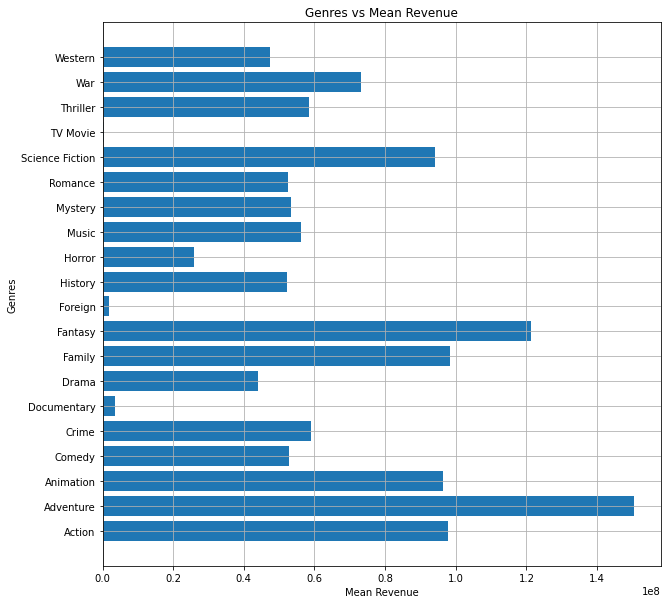

```python
#plot bars to see which geners have the most revenue mean
plt.figure(figsize=(10,10));
plt.barh(revenue_mean_based_on_genres.index, revenue_mean_based_on_genres.values)
plt.title('Genres vs Mean Revenue')
plt.ylabel('Genres')
plt.xlabel('Mean Revenue')
plt.grid(True);
```

As you can see from the plot above **Adverture** have the highest mean revenue.

## Limitations

1. budget_adj and revenue_adj have alot of zeros values.
2. Delete the missing value effect the result